# Time-removal models

Analysing Ecological Data with Detection Error

Author

Péter Sólymos

Published

April 22, 2026

# Preamble

```r
library(bSims) # startup message is actually interesting
```

```
mefa4 0.3-12     2025-07-12
```

```
deldir 2.0-4      Nickname: "Idol Comparison"
```

```
     The syntax of deldir() has changed since version
     0.0-10.  Read the help!!!.
```

```
bSims 0.3-3      2025-07-12      kip-kip-kip
```

```r
library(detect)
```

```
detect 0.5-1     2026-01-04
```

```r
set.seed(1234)
```

Let’s build a simple unstratified landscape: extent is given in 100 m units as we saw before

```r
(l <- bsims_init(extent = 10))
```

```
bSims landscape
  1 km x 1 km
  stratification: H
```

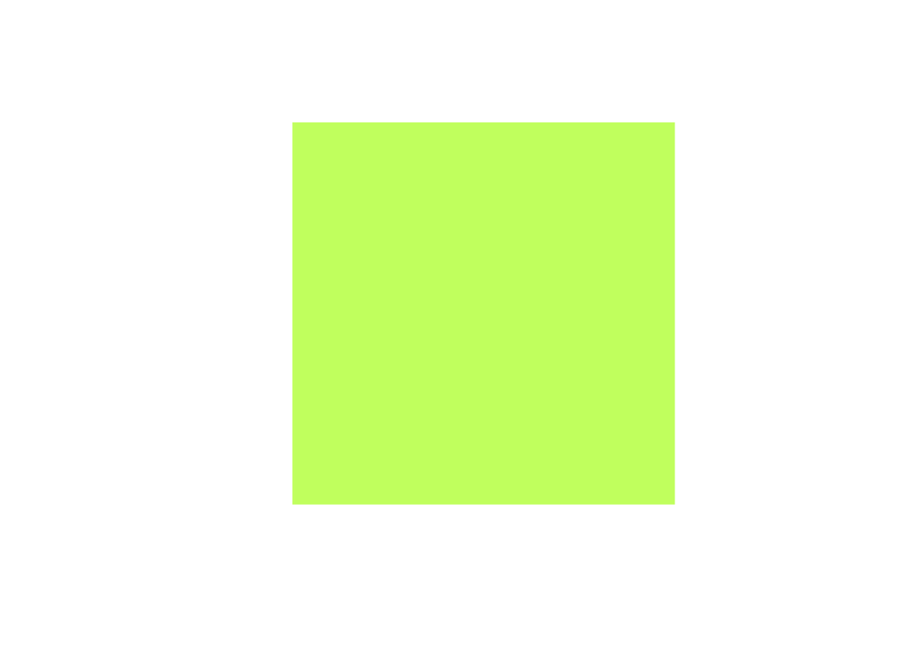

```r
plot(l)
```

```r
(a <- bsims_populate(l, density = 0.5))
```

```
bSims population
  1 km x 1 km
  stratification: H
  total abundance: 44
```

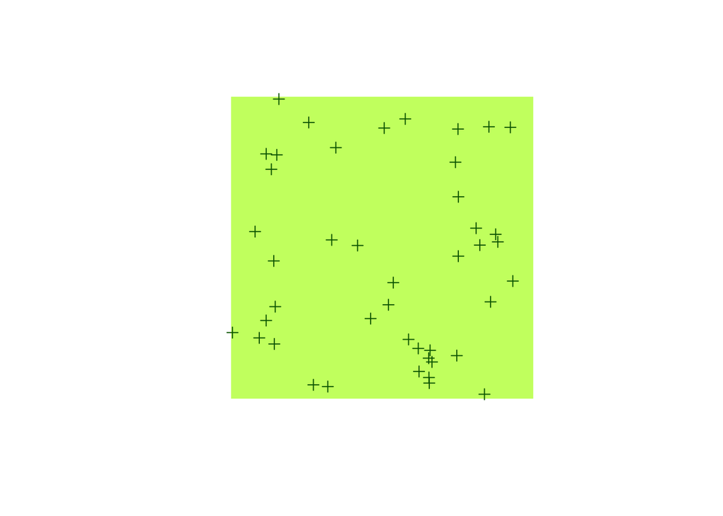

```r
plot(a)
```

The locations can be seen as nest locations (`i` is the individual ID, `s` is the stratum where that nest is located, `x` and `y` are the coordinates of the nests, ignore column `g` for now):

```r
head(get_nests(a))
```

```
  i s         x          y  g
1 1 H -1.798447 -4.6000408 NA
2 2 H -4.952521 -2.8120046 NA
3 3 H -3.837247  3.1059855 NA
4 4 H -1.669581  0.2569755 NA
5 5 H -2.428744  4.1465817 NA
6 6 H -1.532044  3.3134505 NA
```

We can conveniently extract abundance and density:

```r
get_abundance(a) # abundance
```

```
[1] 44
```

```r
get_density(a) # density
```

```
[1] 0.44
```

```r
get_abundance(a) / get_density(a) # area
```

```
[1] 100
```

Bring the population to life (ignoring movement)

```r
(b <- bsims_animate(a,
    vocal_rate = 0.5, duration = 10
))
```

```
bSims events
  1 km x 1 km
  stratification: H
  total abundance: 44
  duration: 10 min
```

The `get_events` function extracts the events as a data frame with columns describing the location (`x`, `y`) and time (`t`) of the events (`v` is 1 for vocalizations and 0 otherwise) for each individual (`i` gives the individual identifier that links individuals to the nest locations)

```r
v <- get_events(b)
head(v)
```

```
          x          y          t v   a  i
1  3.385473 -4.8537274 0.04797183 1 223 24
2 -4.066386 -2.9875196 0.05211486 1 182 14
3  3.827299  0.1918998 0.13695644 1  28 27
4  3.756001  0.4426976 0.16492412 1 164 35
5  1.648851 -3.7851981 0.16634146 1 284 22
6 -3.838870 -2.4119018 0.22107220 1 223 15
```

# Survival model

Survival models assess time-to-event data which is often censored (some event has not occurred at the time the data collection ended).

Event time ($T$) is a continuous random variable. In the simplest case, its probability density function is the Exponential distribution: $f(t)=\phi e^{-t\phi}$. The corresponding cumulative distribution function is: $F(t)=\int_{0}^{t} f(t)dt=1-e^{-t\phi}$, giving the probability that the event has occurred by duration $t$ and we will refer to this probability as $p_t$. The parameter $\phi$ is the rate of the Exponential distribution with mean $1/\phi$ and variance $1/\phi^2$.

This simplest survival distribution assumes constant risk over time ($\lambda(t)=\phi$), which corresponds to the Exponential distribution. The Exponential distribution also happens to describe the lengths of the inter-event times in a homogeneous Poisson process (events are independent, ‘memory-less’ process).

# Vocalization events

Let’s put movement aside for now. Event times in our bSims example follow a Poisson process with rate $\phi$ (`vocal_rate=0.5`) within `duration` $t=10$ minutes.

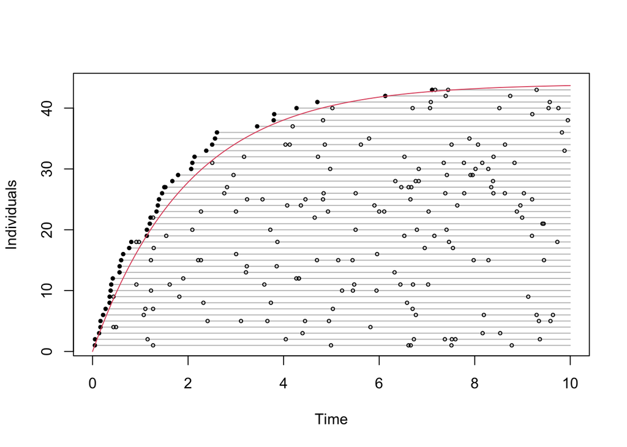

```r
plot(v)
curve((1 - exp(-0.5 * x)) * get_abundance(b), col = 2, add = TRUE)
```

Now instead of the cumulative density function (above), we look at the time to 1st detection data: we get that by taking the 1st mention of the individual IDs. The table is sorted by `t`, so the non-duplicated mentions of the individuals will give us the time it was 1st detected.

Let’s subset the vocalization events to include the times of first detection for each individual (`v1`). The estimated rate should match our settings, the plot shows the Exponential probability density function on top of the event times:

```r
v1 <- v[!duplicated(v$i), ]
head(v1)
```

```
          x          y          t v   a  i
1  3.385473 -4.8537274 0.04797183 1 223 24
2 -4.066386 -2.9875196 0.05211486 1 182 14
3  3.827299  0.1918998 0.13695644 1  28 27
4  3.756001  0.4426976 0.16492412 1 164 35
5  1.648851 -3.7851981 0.16634146 1 284 22
6 -3.838870 -2.4119018 0.22107220 1 223 15
```

We use the `fitdistr` function to fit an exponential distribution to these event times:

```r
phi <- 0.5
(phi_hat <- fitdistr(v1$t, "exponential")$estimate)
```

```
     rate
0.5996346
```

```r
# which is the same as 1/mean(v1$t)
1 / mean(v1$t)
```

```
[1] 0.5996346
```

The estimate is close to the true value of 0.5. Let’s plot this

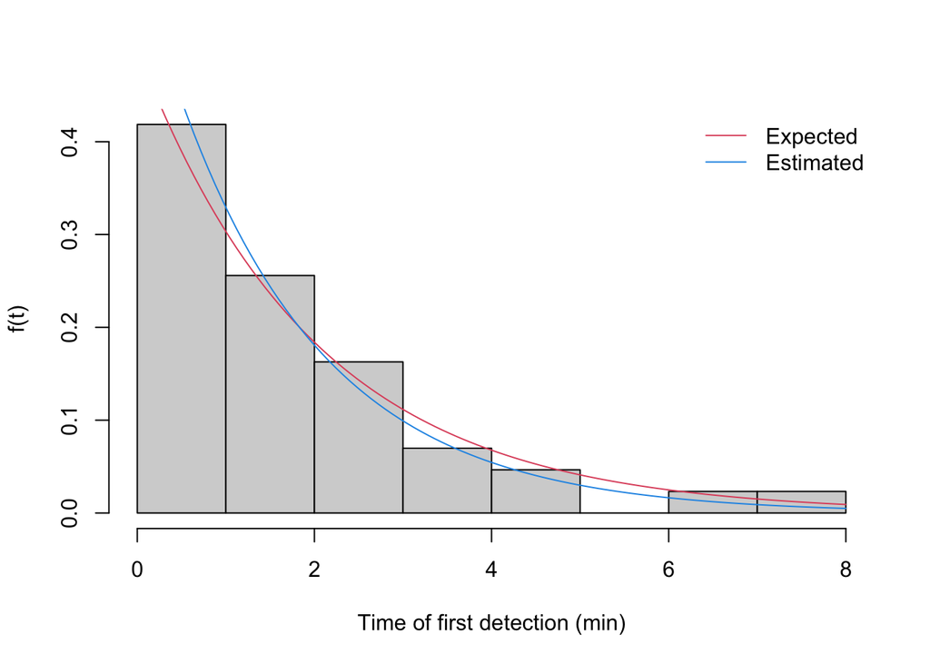

```r
hist(v1$t,
    xlab = "Time of first detection (min)", freq = FALSE, main = "",
    col = "lightgrey", ylab = "f(t)"
)
curve(dexp(x, phi), add = TRUE, col = 2)
curve(dexp(x, phi_hat), add = TRUE, col = 4)
legend("topright",
    bty = "n", lty = 1, col = c(2, 4),
    legend = c("Expected", "Estimated")
)
```

Now let’s visualize the corresponding cumulative distribution function. We also bin the events into time intervals defined by interval end times in the vector `br` (breaks to be used with `cut`):

```r
br <- c(3, 5, 10)
i <- cut(v1$t, c(0, br), include.lowest = TRUE)
table(i)
```

```
i
 [0,3]  (3,5] (5,10]
    36      5      2
```

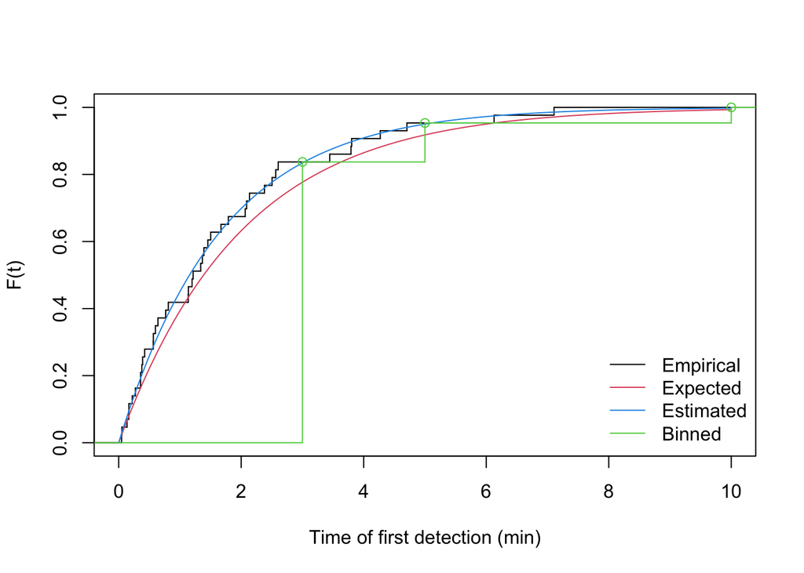

```r
plot(stepfun(v1$t, (0:nrow(v1)) / nrow(v1)),
    do.points = FALSE, xlim = c(0, 10),
    xlab = "Time of first detection (min)", ylab = "F(t)", main = ""
)
curve(1 - exp(-phi * x), add = TRUE, col = 2)
curve(1 - exp(-phi_hat * x), add = TRUE, col = 4)
lines(stepfun(br, c(0, cumsum(table(i)) / sum(table(i)))), col = 3)
legend("bottomright",
    bty = "n", lty = c(1, 1, 1, 1), col = c(1, 2, 4, 3),
    legend = c("Empirical", "Expected", "Estimated", "Binned")
)
```

Fitting survival model to the time-to-event data

```r
library(survival)
t21 <- v1$t
y01 <- ifelse(is.na(t21), 0, 1)
# censoring at max when we have nondetections (not here but in general)
t21[is.na(t21)] <- attr(v1, "tlim")[2]
# time cannot be 0, so we use a small number instead
t21[t21 == 0] <- 0.001
# survival object
sv <- Surv(t21, y01)
m <- survreg(sv ~ 1, dist = "exponential")
1 / exp(coef(m))
```

```
(Intercept)
  0.5996346
```

# Removal model

The time-removal model, originally developed for estimating wildlife and fish abundances from mark-recapture studies, was later reformulated for avian surveys with the goal of improving estimates of bird abundance by accounting for the availability bias inherent in point-count data. The removal model applied to point-count surveys estimates the probability that a bird is available for detection as a function of the average number of detectable cues that an individual bird gives per minute (singing rate, $\phi$), and the known count duration ($t$).

Time-removal models are based on a removal experiment whereby animals are trapped and thereby removed from the closed population of animals being sampled. When applying a removal model to avian point-count surveys, the counts of singing birds ($Y_{ij}, \ldots, Y_{iJ}$) within a given point-count survey $i$ ($i = 1,\ldots, n$) are tallied relative to when each bird is first detected in multiple and consecutive time intervals, with the survey start time $t_{i0} = 0$, the end times of the time intervals $t_{ij}$ ($j = 1, 2,\ldots, J$), and the total count duration of the survey
$$t_{iJ}$$
. We count each individual bird once, so individuals are ‘mentally removed’ from a closed population of undetected birds by the surveyor.

The continuous-time formulation of the removal model is identical to the Exponential survival model formulation with respect to the cumulative density function, which defines probability of availability for sampling given the occurrence of the species. The response variable in the removal model follows multinomial distribution with cell probabilities derived from the cumulative probability function.

We will use the `detect::cmulti` function to fit multinomial models using conditional maximum likelihood procedure (the conditioning means that we only use observations where the total count is not 0, i.e. the species was present). The `Y` matrix lists the number of new individuals counted in each time interval, the `D` matrix gives the interval end times. (We use the `detect::cmulti.fit` function to be able to fit the model to a single survey.)

```r
(y <- matrix(as.numeric(table(i)), nrow = 1))
```

```
     [,1] [,2] [,3]
[1,]   36    5    2
```

```r
(d <- matrix(br, nrow = 1))
```

```
     [,1] [,2] [,3]
[1,]    3    5   10
```

```r
phi_hat1 <- exp(cmulti.fit(y, d, type = "rem")$coef)

c(
    True = phi, # setting
    T21 = phi_hat, # from time-to-event data
    Rem = phi_hat1
)
```

```
     True  T21.rate       Rem
0.5000000 0.5996346 0.6018970
```

Notice that estimates can be off relative the true value. Time to 1st event data provides more information (exact times of events), the binned approach looses that information, and as a result can be more variable. Historically, the collection of time-to-1st event data has been difficult in the field. If a recording exists, this can be added. We’ll talk more about recordings later.

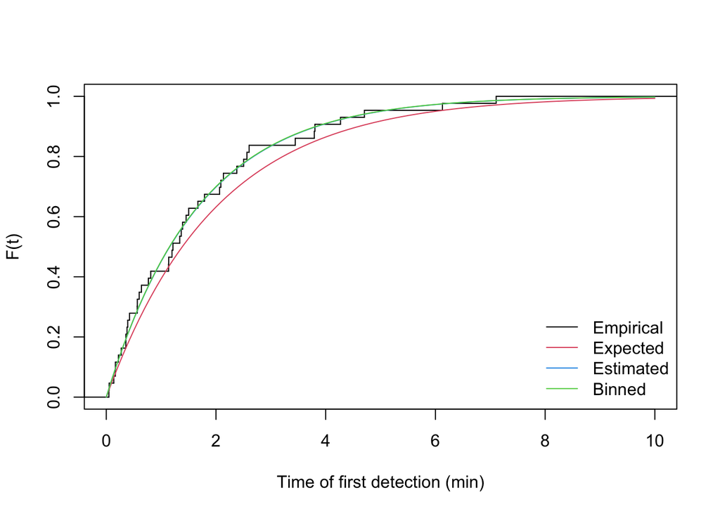

```r
plot(stepfun(v1$t, (0:nrow(v1)) / nrow(v1)),
    do.points = FALSE, xlim = c(0, 10),
    xlab = "Time of first detection (min)", ylab = "F(t)", main = ""
)
curve(1 - exp(-phi * x), add = TRUE, col = 2)
curve(1 - exp(-phi_hat * x), add = TRUE, col = 4)
curve(1 - exp(-phi_hat1 * x), add = TRUE, col = 3)
legend("bottomright",
    bty = "n", lty = c(1, 1, 1, 1), col = c(1, 2, 4, 3),
    legend = c("Empirical", "Expected", "Estimated", "Binned")
)
```

# Real data

Let’s pick a species from the JOSM data set. For predictors, we will use a variable capturing date (`DAY`; standardized ordinal day of the year) and an other one capturing time of day (`TSSR`; time since local sunrise, see the suntools package). The data frame `X` contains the predictors. The matrix `Y` contains the counts of newly counted individuals binned into consecutive time intervals: cell values are the $Y_{ij}$’s. The `D` object is another matrix mirroring the structure of `Y` but instead of counts, it contains the interval end times: cell values are the $t_{ij}$’s.

```r
yall <- Xtab(
    ~ SiteID + Dur + SpeciesID,
    detect::josm$counts[detect::josm$counts$DetectType1 != "V", ]
)
yall <- yall[sapply(yall, function(z) sum(rowSums(z) > 0)) > 100]

spp <- "TEWA"

Y <- as.matrix(yall[[spp]])
D <- matrix(c(3, 5, 10), nrow(Y), 3,
    byrow = TRUE,
    dimnames = dimnames(Y)
)
X <- detect::josm$surveys[rownames(Y), c("DAY", "TSSR")]
head(Y[rowSums(Y) > 0, ])
```

```
        0-3min 3-5min 5-10min
CL10106      4      0       0
CL10112      2      0       0
CL10120      1      1       0
CL10170      1      0       0
CL10172      0      0       2
CL10181      0      0       1
```

```r
head(D)
```

```
        0-3min 3-5min 5-10min
CL10102      3      5      10
CL10106      3      5      10
CL10108      3      5      10
CL10109      3      5      10
CL10111      3      5      10
CL10112      3      5      10
```

```r
summary(X)
```

```
      DAY              TSSR
 Min.   :0.3918   Min.   :-0.02854
 1st Qu.:0.4219   1st Qu.: 0.05059
 Median :0.4521   Median : 0.10407
 Mean   :0.4495   Mean   : 0.10396
 3rd Qu.:0.4740   3rd Qu.: 0.15676
 Max.   :0.5041   Max.   : 0.23568
```

The `D` matrix can take different methodologies for each row. The leftover values in each row must be filled with `NA`s and the pattern of `NA`s must match between the `Y` and `D` matrices (i.e. you shouldn’t have observation in a non-existing time interval). Integrating data becomes really easy this way, for example `D` can look like this (whatever the time unit is, e.g. min, that is what event rate is going to be measured in, e.g. 1/min):

```r
matrix(c(3, 5, 10, NA, NA, 1:5, 4, 8, NA, NA, NA), 3, byrow = TRUE)
```

```
     [,1] [,2] [,3] [,4] [,5]
[1,]    3    5   10   NA   NA
[2,]    1    2    3    4    5
[3,]    4    8   NA   NA   NA
```

# Time-invariant conventional removal model

Time-invariant means that the rate is constant over time (i.e. no difference between morning and midnight), while conventional refers to the assumption that all individuals share the same rate (their behavior is identical in this regard).

In the time-invariant conventional removal model (`Me0`), the individuals of a species at a given location and time are assumed to be homogeneous in their singing rates. The time to first detection follows the Exponential distribution, and the cumulative density function of times to first detection in time interval (0, $t_{iJ}$) gives us the probability that a bird sings at least once during the point count as $p(t_{iJ}) = 1 - exp(-t_{iJ} \phi)$.

We fit this model by specifying intercept-only in the right hand side of the formula, and `type="rem"` as part of the `cmulti` call:

```r
Me0 <- cmulti(Y | D ~ 1, type = "rem")
summary(Me0)
```

```
Call:
cmulti(formula = Y | D ~ 1, type = "rem")

Removal Sampling (homogeneous singing rate)
Conditional Maximum Likelihood estimates

Coefficients:
                    Estimate Std. Error z value Pr(>|z|)
log.phi_(Intercept) -0.85470    0.01739  -49.15   <2e-16 ***
---
Signif. codes:  0 '***' 0.001 '**' 0.01 '*' 0.05 '.' 0.1 ' ' 1

Log-likelihood: -3205
BIC =  6418
```

```r
(phi_Me0 <- exp(coef(Me0)))
```

```
log.phi_(Intercept)
            0.42541
```

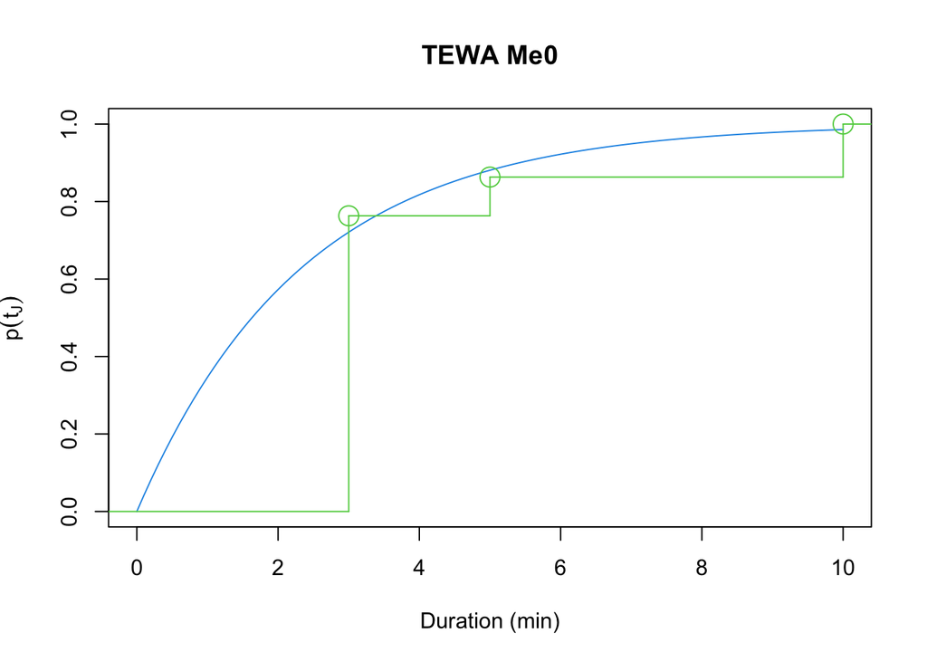

```r
curve(1 - exp(-x * phi_Me0),
    xlim = c(0, 10), ylim = c(0, 1), col = 4,
    xlab = "Duration (min)", ylab = expression(p(t[J])),
    main = paste(spp, "Me0")
)
lines(stepfun(D[1, ], c(0, cumsum(colSums(Y)) / sum(Y))), cex = 2, col = 3, pch = 21)
```

# Time-varying conventional removal model

Singing rates of birds vary with time of day, time of year, breeding status, and stage of the nesting cycle. Thus, removal model estimates of availability may be improved by accounting for variation in singing rates using covariates for day of year and time of day. In this case $p(t_{iJ}) = 1 - e^{-t_{iJ} \phi_{i}}$ and $log(\phi_{i}) = \beta_{0} + \sum^{K}_{k=1} \beta_{k} x_{ik}$ is the linear predictor with $K$ covariates and the corresponding unknown coefficients ($\beta_{k}$, $k = 0,\ldots, K$).

Let’s fit a couple of time-varying models using `DAY` and `TSSR` as covariates:

```r
Me1 <- cmulti(Y | D ~ DAY, X, type = "rem")
Me2 <- cmulti(Y | D ~ TSSR, X, type = "rem")
```

Now compare the three conventional models based on AIC and inspect the summary for the best supported model with the `DAY` effect.

```r
Me_AIC <- AIC(Me0, Me1, Me2)
Me_AIC$delta_AIC <- Me_AIC$AIC - min(Me_AIC$AIC)
Me_AIC[order(Me_AIC$AIC), ]
```

```
    df      AIC delta_AIC
Me1  2 6401.136   0.00000
Me2  2 6411.423  10.28765
Me0  1 6411.843  10.70752
```

```r
Me_Best <- get(rownames(Me_AIC)[Me_AIC$delta_AIC == 0])
summary(Me_Best)
```

```
Call:
cmulti(formula = Y | D ~ DAY, data = X, type = "rem")

Removal Sampling (homogeneous singing rate)
Conditional Maximum Likelihood estimates

Coefficients:
                    Estimate Std. Error z value Pr(>|z|)
log.phi_(Intercept)  0.07841    0.26149   0.300 0.764274
log.phi_DAY         -2.09097    0.58661  -3.565 0.000365 ***
---
Signif. codes:  0 '***' 0.001 '**' 0.01 '*' 0.05 '.' 0.1 ' ' 1

Log-likelihood: -3199
BIC =  6413
```

```r
MuMIn::model.sel(Me0, Me1, Me2)
```

```
Model selection table
    (Intrc) D Y DAY TSSR df    logLik   AICc delta weight
Me1       + + +   +       2 -3198.568 6401.1  0.00  0.990
Me2       + + +        +  2 -3203.712 6411.4 10.29  0.006
Me0       + + +           1 -3204.922 6411.8 10.70  0.005
Models ranked by AICc(x)
```

To visually capture the time-varying effects, we make some plots using base graphics, colors matching the time-varying predictor. This way we can not only assess how availability probability (given a fixed time interval) is changing with the values of the predictor, but also how the cumulative distribution changes with time.

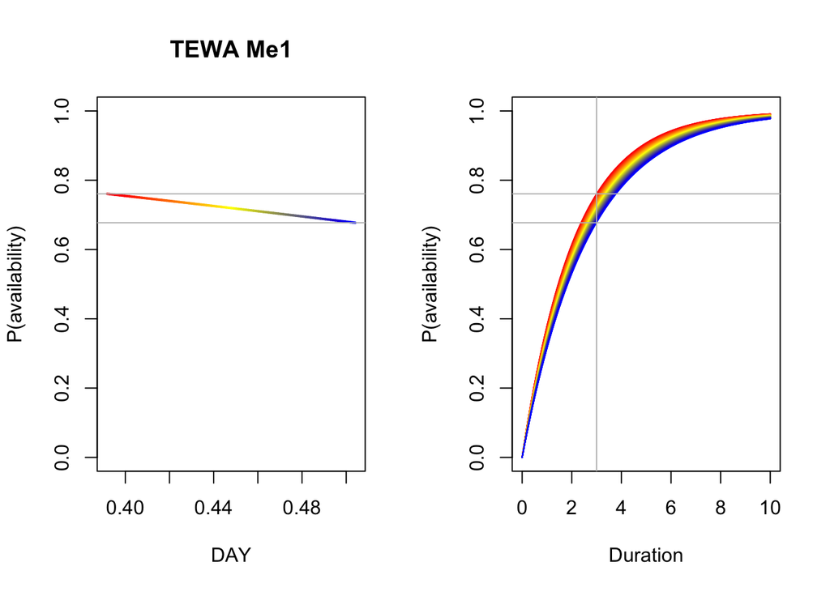

```r
b <- coef(Me_Best)

n <- 100
DAY <- seq(min(X$DAY), max(X$DAY), length.out = n + 1)
TSSR <- seq(min(X$TSSR), max(X$TSSR), length.out = n + 1)
Duration <- seq(0, 10, length.out = n)
col <- colorRampPalette(c("red", "yellow", "blue"))(n)

op <- par(mfrow = c(1, 2))
p1 <- 1 - exp(-3 * exp(b[1] + b[2] * DAY))
plot(DAY, p1,
    ylim = c(0, 1), type = "n",
    main = paste(spp, rownames(Me_AIC)[Me_AIC$delta_AIC == 0]),
    ylab = "P(availability)"
)
for (i in seq_len(n)) {
    lines(DAY[c(i, i + 1)], p1[c(i, i + 1)], col = col[i], lwd = 2)
}
abline(h = range(p1), col = "grey")

plot(Duration, Duration,
    type = "n", ylim = c(0, 1),
    ylab = "P(availability)"
)
for (i in seq_len(n)) {
    p2 <- 1 - exp(-Duration * exp(b[1] + b[2] * DAY[i]))
    lines(Duration, p2, col = col[i])
}
abline(v = 3, h = range(p1), col = "grey")
```

```r
par(op)
```

# Under the hood

So what is really happening when we fit a removal model?

1. We use conditional maximum likelihood, which means that we only look at survey data where al least 1 individual was detected
2. We assign the 1st detection of every new individual to a time interval, but do not count any subsequent detections of the already tallied individuals
3. The counts within the time intervals are treated as a Multinomial response with $Y$ being the total count (sum of new individuals)
4. The cell probabilities are calculated based on the cumulative density function
5. The cell probabilities are parametrized based on the rate parameter, which can also depend on covariates using a logarithmic link function
6. The conditional likelihood function is maximized with respect to the data given the betas

# Finite Mixture Models

Let’s relax the assumption that all individuals vocalize at the same rate. We can think about this as different groups in the population. The individuals within the groups have homogenerous rates, but the group level rates are different. We can introduce such heterogeneity into our bSims world by specifying the group level rates (`phi` vector) and the proportion of individuals belonging to the groups (`mix`).

```r
phi <- c(10, 0.5)
mix <- c(0.25, 0.75)

l <- bsims_init(extent = 10)
(a2 <- bsims_populate(l, density = 1)) # increase density
```

```
bSims population
  1 km x 1 km
  stratification: H
  total abundance: 104
```

```r
(b2 <- bsims_animate(a2, vocal_rate = phi, mixture = mix))
```

```
bSims events
  1 km x 1 km
  stratification: H
  total abundance: 104
  mixture, duration: 10 min
```

```r
b2$vocal_rate
```

```
  G1  G2
H 10 0.5
E 10 0.5
R 10 0.5
```

If we plot the time to first detection data, we can see how expected distribution (red) is different from the fitted Exponential distribution assuming homogeneity:

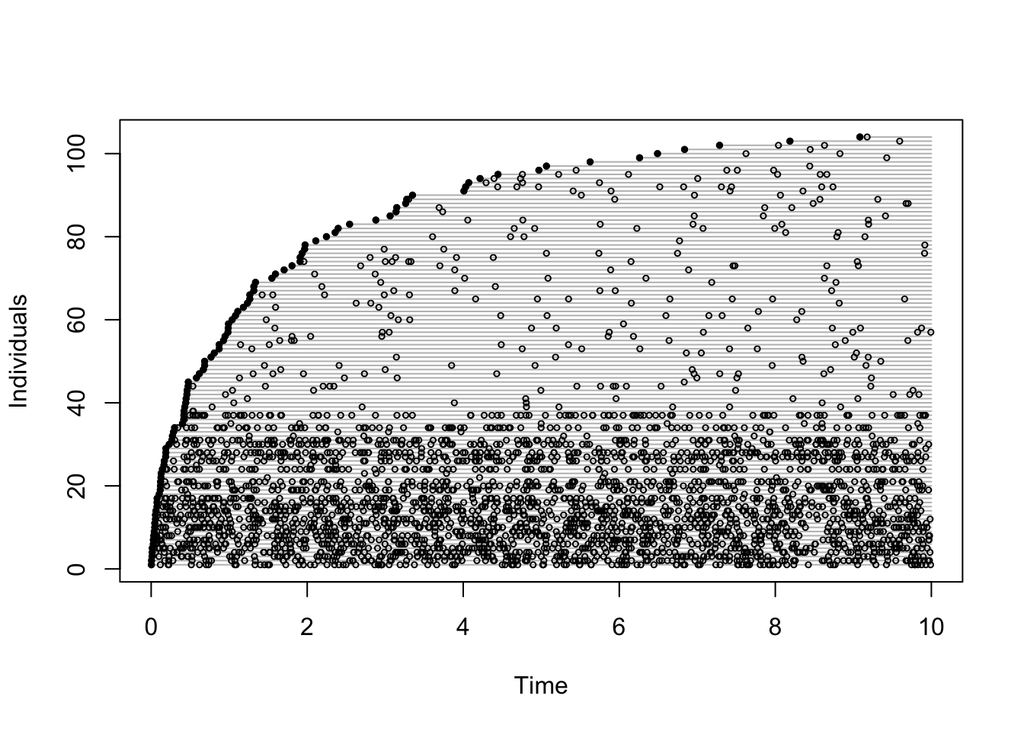

```r
v <- get_events(b2)
plot(v)
```

```r
v1 <- v[!duplicated(v$i), ]
(phi_hat <- fitdistr(v1$t, "exponential")$estimate)
```

```
     rate
0.6385952
```

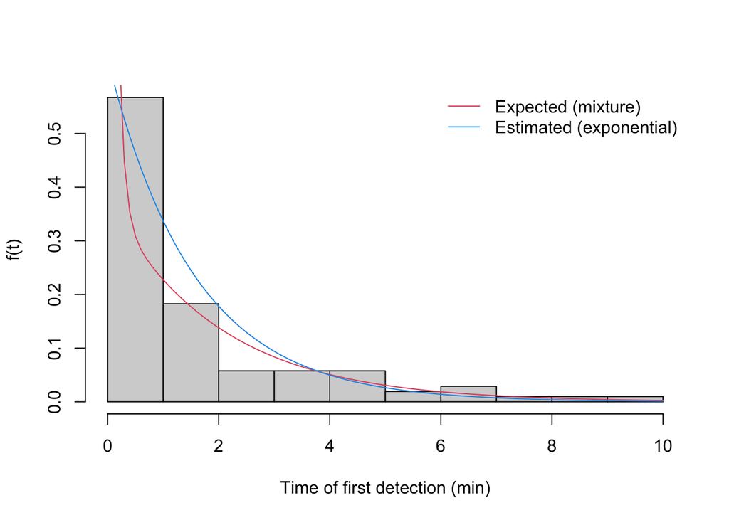

```r
hist(v1$t,
    xlab = "Time of first detection (min)", freq = FALSE, main = "",
    col = "lightgrey", ylab = "f(t)"
)
curve(mix[1] * dexp(x, phi[1]) + mix[2] * dexp(x, phi[2]), add = TRUE, col = 2)
curve(dexp(x, phi_hat), add = TRUE, col = 4)
legend("topright",
    bty = "n", lty = 1, col = c(2, 4),
    legend = c("Expected (mixture)", "Estimated (exponential)")
)
```

Now let’s visualize the corresponding cumulative distribution function:

```r
br <- 1:10
i <- cut(v1$t, c(0, br), include.lowest = TRUE)
table(i)
```

```
i
 [0,1]  (1,2]  (2,3]  (3,4]  (4,5]  (5,6]  (6,7]  (7,8]  (8,9] (9,10]
    59     19      6      6      6      2      3      1      1      1
```

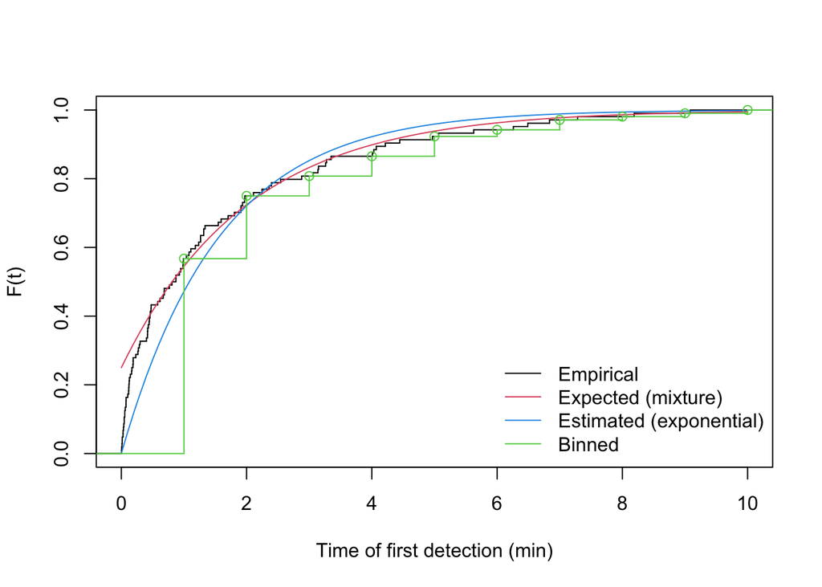

```r
plot(stepfun(v1$t, (0:nrow(v1)) / nrow(v1)),
    do.points = FALSE, xlim = c(0, 10),
    xlab = "Time of first detection (min)", ylab = "F(t)", main = ""
)
curve(1 - mix[2] * exp(-phi[2] * x), add = TRUE, col = 2)
curve(1 - exp(-phi_hat * x), add = TRUE, col = 4)
lines(stepfun(br, c(0, cumsum(table(i)) / sum(table(i)))), col = 3)
legend("bottomright",
    bty = "n", lty = c(1, 1, 1, 1), col = c(1, 2, 4, 3),
    legend = c("Empirical", "Expected (mixture)", "Estimated (exponential)", "Binned")
)
```

We use the `detect::cmulti` function to fit the finite mixture model:

```r
(y <- matrix(as.numeric(table(i)), nrow = 1))
```

```
     [,1] [,2] [,3] [,4] [,5] [,6] [,7] [,8] [,9] [,10]
[1,]   59   19    6    6    6    2    3    1    1     1
```

```r
(d <- matrix(br, nrow = 1))
```

```
     [,1] [,2] [,3] [,4] [,5] [,6] [,7] [,8] [,9] [,10]
[1,]    1    2    3    4    5    6    7    8    9    10
```

```r
cf <- cmulti.fit(y, d, type = "fmix")$coef # log.phi, logit.c

cbind(
    True = c(phi = phi[2], c = mix[2]),
    Removal = c(phi_hat = exp(cf[1]), c_hat = plogis(cf[2]))
)
```

```
    True   Removal
phi 0.50 0.4006807
c   0.75 0.6560419
```

# Time-invariant finite mixture removal model

The removal model can accommodate behavioral heterogeneity in singing by subdividing the sampled population for a species at a given point into a finite mixture of birds with low and high singing rates, which requires the additional estimation of the proportion of birds in the sampled population with low singing rates.

In the continuous-time formulation of the finite mixture (or two-point mixture) removal model, the cumulative density function during a point count is given by $p(t_{iJ}) = (1 - c) 1 + c (1 - e^{-t_{iJ} \phi}) = 1 - c e^{-t_{iJ} \phi}$, where $\phi$ is the singing rate for the group of infrequently singing birds, and $c$ is the proportion of birds during the point count that are infrequent singers. The remaining proportions ($1 - c$; the intercept of the cumulative density function) of the frequent singers are assumed to be detected instantaneously at the start of the first time interval. In the simplest form of the finite mixture model, the proportion and singing rate of birds that sing infrequently is homogeneous across all times and locations (model `Mf0`). We are using the `type = "fmix"` for finite mixture removal models.

Have a look at the real bird data set:

```r
Mf0 <- cmulti(Y | D ~ 1, type = "fmix")
summary(Mf0)
```

```
Call:
cmulti(formula = Y | D ~ 1, type = "fmix")

Removal Sampling (heterogeneous singing rate)
Conditional Maximum Likelihood estimates

Coefficients:
                    Estimate Std. Error z value Pr(>|z|)
log.phi_(Intercept) -1.71461    0.09698  -17.68   <2e-16 ***
logit.c              0.07418    0.05981    1.24    0.215
---
Signif. codes:  0 '***' 0.001 '**' 0.01 '*' 0.05 '.' 0.1 ' ' 1

Log-likelihood: -3102
BIC =  6219
```

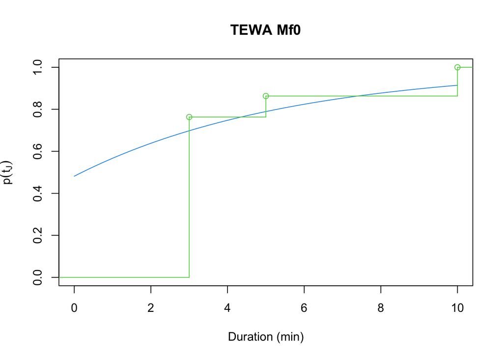

```r
cf_Mf0 <- coef(Mf0)

curve(1 - plogis(cf_Mf0[2]) * exp(-x * exp(cf_Mf0[1])),
    xlim = c(0, 10), ylim = c(0, 1), col = 4, main = paste(spp, "Mf0"),
    xlab = "Duration (min)", ylab = expression(p(t[J]))
)
lines(stepfun(D[1, ], c(0, cumsum(colSums(Y)) / sum(Y))), col = 3)
```

# Time-varying finite mixture removal models

Previously, researchers have applied covariate effects on the parameter $\phi_{i}$ of the finite mixture model, similarly to how we modeled these effects in conventional models. This model assumes that the parameter $c$ is constant irrespective of time and location (i.e. only the infrequent singer group changes its singing behavior).

We can fit finite mixture models with `DAY` and `TSSR` as covariates on $\phi$. In this case $p(t_{iJ}) = 1 - c e^{-t_{iJ} \phi_{i}}$ and $log(\phi_{i}) = \beta_{0} + \sum^{K}_{k=1} \beta_{k} x_{ik}$ is the linear predictor with $K$ covariates and the corresponding unknown coefficients ($\beta_{k}$, $k = 0,\ldots, K$).

```r
Mf1 <- cmulti(Y | D ~ DAY, X, type = "fmix")
Mf2 <- cmulti(Y | D ~ TSSR, X, type = "fmix")
```

Compare the three finite mixture models based on AIC and inspect the summary for the best supported model:

```r
Mf_AIC <- AIC(Mf0, Mf1, Mf2)
Mf_AIC$delta_AIC <- Mf_AIC$AIC - min(Mf_AIC$AIC)

Mf_Best <- get(rownames(Mf_AIC)[Mf_AIC$delta_AIC == 0])
Mf_AIC[order(Mf_AIC$AIC), ]
```

```
    df      AIC delta_AIC
Mf1  3 6201.851  0.000000
Mf0  2 6207.062  5.211095
Mf2  3 6209.048  7.197169
```

```r
summary(Mf_Best)
```

```
Call:
cmulti(formula = Y | D ~ DAY, data = X, type = "fmix")

Removal Sampling (heterogeneous singing rate)
Conditional Maximum Likelihood estimates

Coefficients:
                    Estimate Std. Error z value Pr(>|z|)
log.phi_(Intercept)  0.75426    0.84821   0.889  0.37388
log.phi_DAY         -5.41168    1.93835  -2.792  0.00524 **
logit.c              0.11897    0.06195   1.920  0.05482 .
---
Signif. codes:  0 '***' 0.001 '**' 0.01 '*' 0.05 '.' 0.1 ' ' 1

Log-likelihood: -3098
BIC =  6220
```

We produce a similar plot as before.

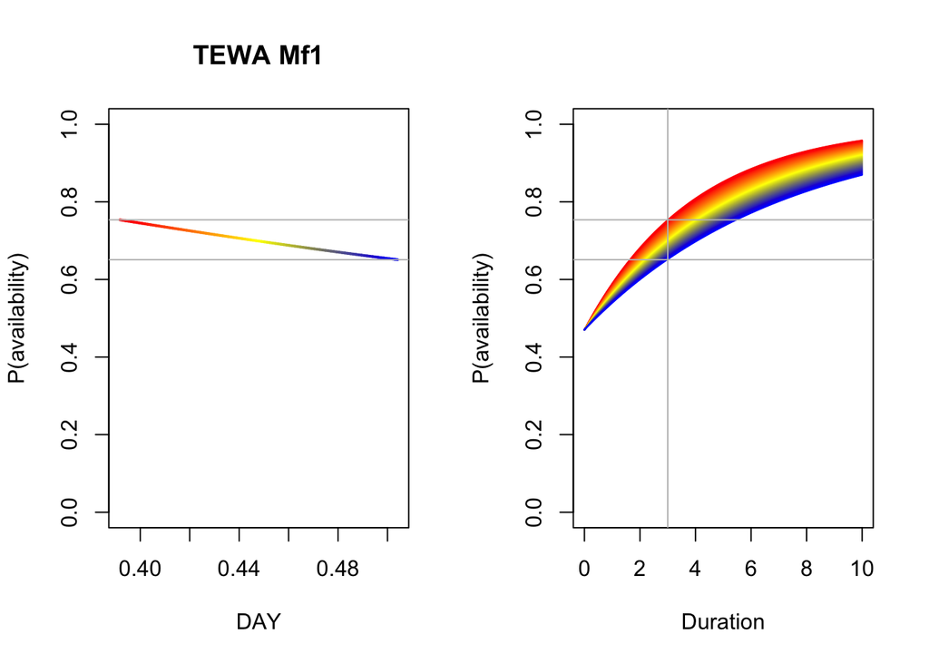

```r
b <- coef(Mf_Best)

op <- par(mfrow = c(1, 2))
p1 <- 1 - plogis(b[3]) * exp(-3 * exp(b[1] + b[2] * DAY))
plot(DAY, p1,
    ylim = c(0, 1), type = "n",
    main = paste(spp, rownames(Mf_AIC)[Mf_AIC$delta_AIC == 0]),
    ylab = "P(availability)"
)
for (i in seq_len(n)) {
    lines(DAY[c(i, i + 1)], p1[c(i, i + 1)], col = col[i], lwd = 2)
}
abline(h = range(p1), col = "grey")

plot(Duration, Duration,
    type = "n", ylim = c(0, 1),
    ylab = "P(availability)"
)
for (i in seq_len(n)) {
    p2 <- 1 - plogis(b[3]) * exp(-Duration * exp(b[1] + b[2] * DAY[i]))
    lines(Duration, p2, col = col[i])
}
abline(v = 3, h = range(p1), col = "grey")
```

```r
par(op)
```

An alternative parametrization is that $c_{i}$ rather than $\phi$ be the time-varying parameter, allowing the individuals to switch between the frequent and infrequent group depending on covariates. We can fit this class of finite mixture model with `DAY` and `TSSR` as covariates on $c$ using `type = "mix"` (instead of `"fmix"`). In this case $p(t_{iJ}) = 1 - c_{i} e^{-t_{iJ} \phi}$ and $logit(c_{i}) = \beta_{0} + \sum^{K}_{k=1} \beta_{k} x_{ik}$ is the linear predictor with $K$ covariates and the corresponding unknown coefficients ($\beta_{k}$, $k = 0,\ldots, K$). Because $c_{i}$ is a proportion, we model it on the logit scale.

```r
Mm1 <- cmulti(Y | D ~ DAY, X, type = "mix")
Mm2 <- cmulti(Y | D ~ TSSR, X, type = "mix")
```

We did not fit a null model for this parametrization, because it is identical to the `Mf0` model, so that model `Mf0` is what we use to compare AIC values and inspect the summary for the best supported model:

```r
Mm_AIC <- AIC(Mf0, Mm1, Mm2)
Mm_AIC$delta_AIC <- Mm_AIC$AIC - min(Mm_AIC$AIC)

Mm_Best <- get(rownames(Mm_AIC)[Mm_AIC$delta_AIC == 0])
Mm_AIC[order(Mm_AIC$AIC), ]
```

```
    df      AIC delta_AIC
Mm1  3 6199.359  0.000000
Mm2  3 6204.405  5.046655
Mf0  2 6207.062  7.703407
```

```r
summary(Mm_Best)
```

```
Call:
cmulti(formula = Y | D ~ DAY, data = X, type = "mix")

Removal Sampling (heterogeneous singing rate)
Conditional Maximum Likelihood estimates

Coefficients:
                    Estimate Std. Error z value Pr(>|z|)
log.phi             -1.71552    0.09696 -17.694  < 2e-16 ***
logit.c_(Intercept) -2.06972    0.69186  -2.992  0.00278 **
logit.c_DAY          4.80419    1.55761   3.084  0.00204 **
---
Signif. codes:  0 '***' 0.001 '**' 0.01 '*' 0.05 '.' 0.1 ' ' 1

Log-likelihood: -3097
BIC =  6217
```

We produce a similar plot as before:

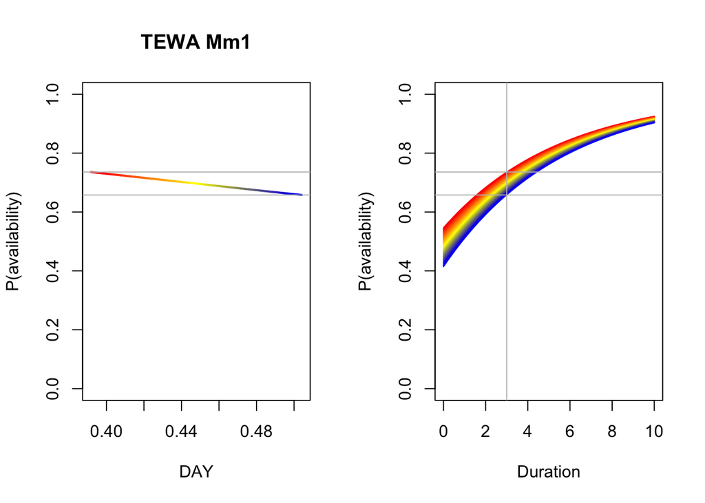

```r
b <- coef(Mm_Best)

op <- par(mfrow = c(1, 2))
p1 <- 1 - plogis(b[2] + b[3] * DAY) * exp(-3 * exp(b[1]))
plot(DAY, p1,
    ylim = c(0, 1), type = "n",
    main = paste(spp, rownames(Mm_AIC)[Mm_AIC$delta_AIC == 0]),
    ylab = "P(availability)"
)
for (i in seq_len(n)) {
    lines(DAY[c(i, i + 1)], p1[c(i, i + 1)], col = col[i], lwd = 2)
}
abline(h = range(p1), col = "grey")

plot(Duration, Duration,
    type = "n", ylim = c(0, 1),
    ylab = "P(availability)"
)
for (i in seq_len(n)) {
    p2 <- 1 - plogis(b[2] + b[3] * DAY[i]) * exp(-Duration * exp(b[1]))
    lines(Duration, p2, col = col[i])
}
abline(v = 3, h = range(p1), col = "grey")
```

```r
par(op)
```

# Let the best model win

So which of the 3 parametrizations proved to be best for our data? It was the finite mixture with time-varying proportion of infrequent singers. Second was the other finite mixture model, while the conventional model was lagging behind.

```r
M_AIC <- AIC(Me0, Me1, Me2, Mf0, Mf1, Mf2, Mm1, Mm2)
M_AIC$delta_AIC <- M_AIC$AIC - min(M_AIC$AIC)
M_AIC[order(M_AIC$AIC), ]
```

```
    df      AIC  delta_AIC
Mm1  3 6199.359   0.000000
Mf1  3 6201.851   2.492312
Mm2  3 6204.405   5.046655
Mf0  2 6207.062   7.703407
Mf2  3 6209.048   9.689481
Me1  2 6401.136 201.776791
Me2  2 6411.423 212.064444
Me0  1 6411.843 212.484315
```

Finite mixture models provide some really nice insight into how singing behavior changes over time and, due to more parameters, they provide a better fit and thus minimize bias in population size estimates. But all this improvement comes with a price: sample size requirements (or more precisely, the number of detections required) are really high. To have all the benefits with reduced variance, one needs about 1000 non-zero observations to fit finite mixture models, 20 times more than needed to reliably fit conventional removal models. This is much higher than previously suggested minimum sample sizes.

Our findings also indicate that lengthening the count duration from 3 minutes to 5–10 minutes is an important consideration when designing field surveys to increase the accuracy and precision of population estimates. Well-informed survey design combined with various forms of removal sampling are useful in accounting for availability bias in point counts, thereby improving population estimates, and allowing for better integration of disparate studies at larger spatial scales.

We also need to realize that eventually the maximum duration is what we use to estimate $p$ to account for availability bias, which is less impacted by the initial shape of the curve when max duration is longer (5-10 mins). However, if the data set is dominated by shorter (3-min) counts, the biases might affect population size estimates more.

## Exercise

Compare different durations, numbers and lengths of time intervals when estimating vocalization rates.

Estimate vocalization rates for other species (e.g. rare species, specias with less frequent vocalizations).

Compare linear and polynomial `DAY` effects for migratory and resident species (e.g. BCCH, BOCH, BRCR, CORA, GRAJ, RBNU).

# Estimating abundance

Let us use the bSims approach to see how well we can estimate abundance after accounting for availability. We set `Den` as density ($D$), and because area is $A$ = 100 ha by default, the expected value of the abundance ($\lambda$) becomes $AD$, while the actual abundance ($N$) is a realization of that based on Poisson distribution ($N \sim Poisson(\lambda)$):

```r
phi <- 0.5
Den <- 1

set.seed(1)
l <- bsims_init()
a <- bsims_populate(l, density = Den)
(b <- bsims_animate(a, vocal_rate = phi, move_rate = 0))
```

```
bSims events
  1 km x 1 km
  stratification: H
  total abundance: 104
  duration: 10 min
```

The next function we use is `bsims_transcribe` which takes the events data and bins it according to time intervals, `tint` defines the end times of each interval. If we skip the detection layer, everything will be detected

```r
tint <- c(1, 2, 3, 4, 5)
(tr <- bsims_transcribe(b, tint = tint))
```

```
bSims transcript
  1 km x 1 km
  stratification: H
  total abundance: 104
  duration: 10 min
  detected: 104 heard
  1st event detected by breaks:
    [0, 1, 2, 3, 4, 5 min]
    [0, Inf m]
```

```r
tr$removal # binned new individuals
```

```
    0-1min 1-2min 2-3min 3-4min 4-5min
0+m     39     20     19      9      9
```

```r
(Y <- sum(tr$removal)) # detected in 0-3 min
```

```
[1] 96
```

After `max(tint)` duration, we detected $Y$ individuals. Because $E[Y] = NC$, we only have to estimate the correction factor $C$, that happens to be $C=p$ in this case because our bSims world ignored the observation process so far. $p$ is estimated based on $\phi$:

```r
fit <- cmulti.fit(tr$removal, matrix(tint, nrow = 1), type = "rem")
c(true = phi, estimate = exp(fit$coef))
```

```
    true estimate
0.500000 0.394072
```

Visualize our estimates

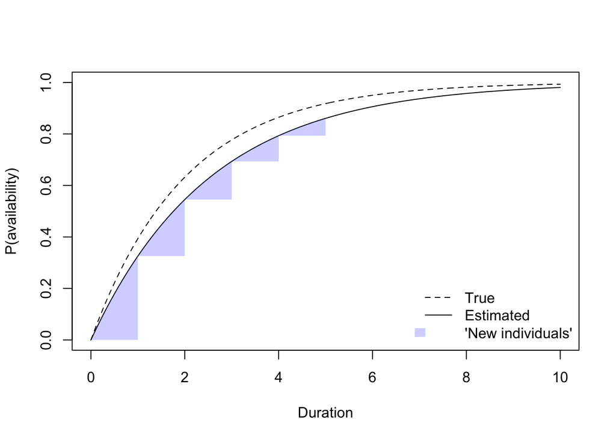

```r
tt <- seq(0, 10, 0.01)
plot(tt, 1 - exp(-tt * phi),
    type = "l", ylim = c(0, 1),
    ylab = "P(availability)", xlab = "Duration", lty = 2
)
lines(tt, 1 - exp(-tt * exp(fit$coef)))
for (i in seq_len(length(tint))) {
    ii <- c(0, tint)[c(i, i + 1)]
    ss <- tt >= ii[1] & tt <= ii[2]
    xi <- tt[ss]
    yi <- 1 - exp(-xi * exp(fit$coef))
    polygon(c(xi, xi[length(xi)]), c(yi, yi[1]),
        border = NA, col = "#0000ff33"
    )
}
legend("bottomright",
    bty = "n", lty = c(2, 1, NA),
    fill = c(NA, NA, "#0000ff33"), border = NA,
    legend = c("True", "Estimated", "'New individuals'")
)
```

$p$ is calculated based on the cumulative density function at `max(tint)`

```r
(p <- 1 - exp(-max(tint) * exp(fit$coef)))
```

```
[1] 0.8605933
```

Our estimate of $N$ becomes $Y/C=Y/p$:

```r
N <- sum(a$abundance)
Nhat <- Y / p
c(true = N, estimate = Nhat)
```

```
    true estimate
104.0000 111.5509
```

In this case, area is known, so density becomes:

```r
A <- sum(a$area)
c(true = N / A, estimate = Nhat / A)
```

```
    true estimate
1.040000 1.115509
```

Do this for the real data set and use our `Best` model:

```r
spp <- "TEWA"

Y <- as.matrix(yall[[spp]])
D <- matrix(c(3, 5, 10), nrow(Y), 3,
    byrow = TRUE,
    dimnames = dimnames(Y)
)
X <- josm$surveys[rownames(Y), c("DAY", "TSSR")]

Best <- get(rownames(M_AIC)[M_AIC$delta_AIC == 0])
summary(Best)
```

```
Call:
cmulti(formula = Y | D ~ DAY, data = X, type = "mix")

Removal Sampling (heterogeneous singing rate)
Conditional Maximum Likelihood estimates

Coefficients:
                    Estimate Std. Error z value Pr(>|z|)
log.phi             -1.71552    0.09696 -17.694  < 2e-16 ***
logit.c_(Intercept) -2.06972    0.69186  -2.992  0.00278 **
logit.c_DAY          4.80419    1.55761   3.084  0.00204 **
---
Signif. codes:  0 '***' 0.001 '**' 0.01 '*' 0.05 '.' 0.1 ' ' 1

Log-likelihood: -3097
BIC =  6217
```

In this case, availability varies due to `DAY`. Our estimate of $N_i$ becomes $Y_i/C_i=Y_i/p_i$:

```r
p <- 1 - plogis(model.matrix(Best) %*% coef(Best)[-1]) *
    exp(-10 * exp(coef(Best)[1]))
summary(p)
```

```
       V1
 Min.   :0.9028
 1st Qu.:0.9087
 Median :0.9130
 Mean   :0.9136
 3rd Qu.:0.9190
 Max.   :0.9250
```

We can now calculate mean abundance, where `ytot` tallies up the counts across the 3 time intervals:

```r
ytot <- rowSums(Y)
table(ytot)
```

```
ytot
   0    1    2    3    4    5    6    7    8   12
1782 1151  887  466  188   71   20    2    1    1
```

```r
mean(ytot / p)
```

```
[1] 1.33685
```

Alternatively, we can fit a GLM and use `log(p)` as an offset:

```r
mod <- glm(ytot ~ 1, family = poisson, offset = log(p))
summary(mod)
```

```
Call:
glm(formula = ytot ~ 1, family = poisson, offset = log(p))

Coefficients:
            Estimate Std. Error z value Pr(>|z|)
(Intercept)  0.29102    0.01338   21.75   <2e-16 ***
---
Signif. codes:  0 '***' 0.001 '**' 0.01 '*' 0.05 '.' 0.1 ' ' 1

(Dispersion parameter for poisson family taken to be 1)

    Null deviance: 7087.6  on 4568  degrees of freedom
Residual deviance: 7087.6  on 4568  degrees of freedom
AIC: 14054

Number of Fisher Scoring iterations: 5
```

The GLM based estimate comes from the intercept, because $E[Y_i]=N_i C_i$ is equivalent to $\lambda_i=e^{\beta_0} e^{o_i}$, this $\hat{N_i}=e^{\hat{\beta_0}}$:

```r
exp(coef(mod))
```

```
(Intercept)
   1.337788
```

This result tells us mean abundance after correcting for availability bias, but we don’t know what area was effectively sampled, and detection of individuals given availability is probably less than 1 because this happens to be a real data set and it is guaranteed that humans in the forest cannot detect birds that are very far (say > 500 m away).

We’ll address these problems next week. Let’s just circle back to the assumptions.

# Exercise 1

What other mechanisms can lead to heterogeneity in behavior?

Use the `run_app("bsimsHER")` Shiny app to explore:

- find “edge cases”
- copy `bsims_all()` calls from Shiny

# Exercise 2

How does over/under counting influence estimated vocalization rates?

(Hint: use the `perception` argument.)

```r
library(bSims)

phi <- 0.5
B <- 10
perc <- seq(0.5, 1.5, 0.1)

l <- expand_list(
    abund_fun = list(identity),
    duration = 10,
    vocal_rate = phi,
    tau = Inf,
    tint = list(c(3, 5, 10)),
    perception = perc
)
str(l[1:2])

# a list of bsims_all objects
# $settings() $new(), $replicate(B, cl)
b <- lapply(l, bsims_all)

# repeat the runs B times for each setting
s <- lapply(b, function(z) {
    z$replicate(B, cl = 4)
})

# removal model
phi_hat <- t(sapply(s, function(r) sapply(r, estimate)["phi", ]))

matplot(perc, phi_hat, lty = 1, type = "l", col = "grey", ylim = c(0, max(phi_hat)))
lines(perc, apply(phi_hat, 1, median), lwd = 2)
abline(h = phi)

matplot(perc, 1 - exp(-1 * phi_hat), lty = 1, type = "l", col = "grey", ylim = c(0, 1))
lines(perc, 1 - exp(-1 * apply(phi_hat, 1, median)), lwd = 2)
abline(h = 1 - exp(-1 * phi), lty = 2)
```

This is how perceived individual ID is deduced using locations:

```r
set.seed(1)
x <- bsims_all(density = 0.1)$new()
perception <- 0.75

z <- get_events(x)
z <- z[!duplicated(z$i), ]
dim(z)
hc <- hclust(dist(cbind(z$x, z$y)), method = "ward.D2")

h <- length(unique(z$i)) * perception
z$j <- cutree(hc, k = min(nrow(z), max(1, round(h))))

plot(hc)
table(true = z$i, perceived = z$j)
plot(z$x, z$y, pch = z$j, col = z$j)
```